# NLB_retail3_analysis

### T: independent t-tests

```r
# employed / unemployed Q: XDS2a4
# Q19 measures importance of sustainability for people

# 2. Data Selection

employmentData <- as.numeric(as.character(mydata[ ,"XDS2a4"]))

# Data cleaned!

# 3. Getting relevant data

# Let's calculate the average view on sustainability per person

viewsOnSustainabilityQ19a <- as.numeric(as.character(mydata[, "Q19a"]))
viewsOnSustainabilityQ19b <- as.numeric(as.character(mydata[, "Q19b"]))
viewsOnSustainabilityQ19c <- as.numeric(as.character(mydata[, "Q19c"]))
viewsOnSustainabilityQ19d <- as.numeric(as.character(mydata[, "Q19d"]))
viewsOnSustainabilityQ19e <- as.numeric(as.character(mydata[, "Q19e"]))

viewsOnSustainability <- as.numeric(as.character(mydata[, "Q19e"])) # Dummy assign

# Here i just calculated the average of all 5 questions when we measured sustainability
for(i in 1:length(viewsOnSustainabilityQ19a)) {
  viewsOnSustainability[i] <- (viewsOnSustainabilityQ19a[i] + viewsOnSustainabilityQ19b[i] + viewsOnSustainabilityQ19c[i] + viewsOnSustainabilityQ19d[i] + viewsOnSustainabilityQ19e[i]) / 5
}

# length(viewsOnSustainability)
# employmentData

viewsOnSustainabilityReference <- data.frame(mydata["Q19a"], mydata["Q19b"], mydata["Q19c"], mydata["Q19d"], mydata["Q19e"])

# viewsOnSustainabilityReference

viewsOnSustainabilityNew <- data.frame(employmentData, viewsOnSustainability)

# viewsOnSustainabilityNew

viewsOnSustainabilityNew$EmployedF <- factor(viewsOnSustainabilityNew$employmentData, levels = c(1, 2), labels = c("Yes", "No"))

library(psych)
describeBy(viewsOnSustainabilityNew$viewsOnSustainability, viewsOnSustainabilityNew$EmployedF)
```

```
##
##  Descriptive statistics by group
## group: Yes
##    vars   n mean   sd median trimmed  mad min max range  skew kurtosis   se
## X1    1 158 5.23 1.04    5.4    5.28 1.19   2   7     5 -0.49    -0.12 0.08
## ------------------------------------------------------------
## group: No
##    vars  n mean   sd median trimmed  mad min max range  skew kurtosis   se
## X1    1 59 5.08 1.02    5.2    5.15 0.89 2.2   7   4.8 -0.58    -0.17 0.13
```

```r
# viewsOnSustainabilityNew
```

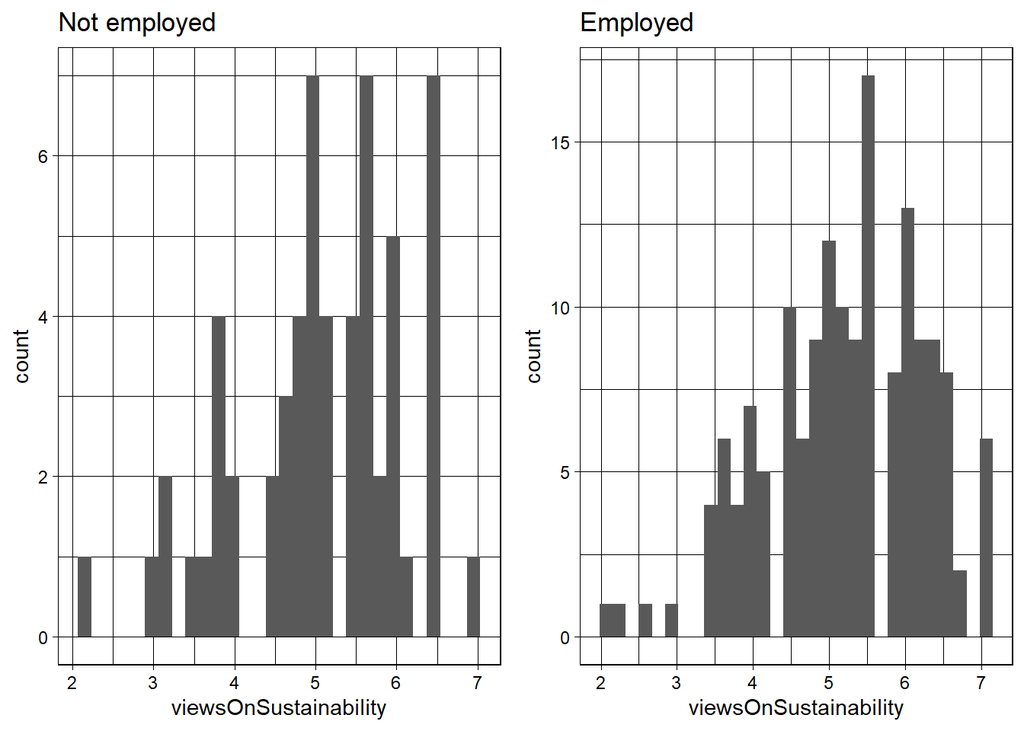

```r
library(ggplot2)

Employed_no <- ggplot(viewsOnSustainabilityNew[viewsOnSustainabilityNew$EmployedF=="No", ], aes(x = viewsOnSustainability)) + theme_linedraw() + geom_histogram() + ggtitle("Not employed")

# Employed_no

Employed_yes <- ggplot(viewsOnSustainabilityNew[viewsOnSustainabilityNew$EmployedF=="Yes", ], aes(x = viewsOnSustainability)) + theme_linedraw() + geom_histogram() + ggtitle("Employed")

#Employed_yes

library(ggpubr)

ggarrange(Employed_no, Employed_yes, ncol = 2, nrow = 1)
```

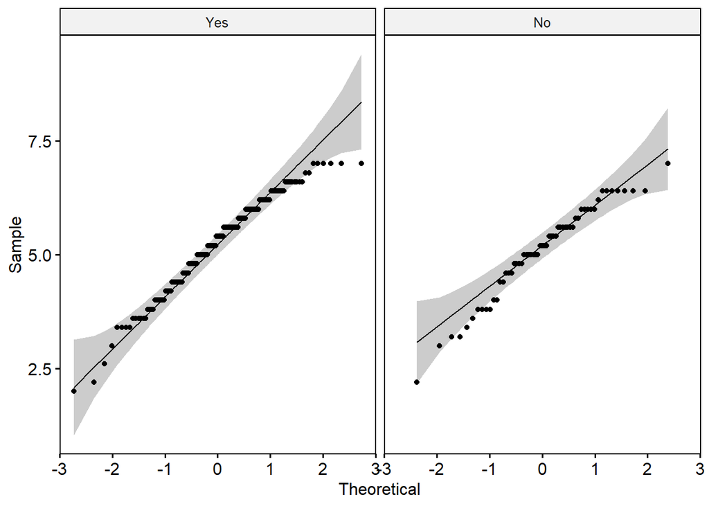

```r
ggqqplot(viewsOnSustainabilityNew, "viewsOnSustainability", facet.by = "EmployedF")
```

```r
# some variables should probably be removed
```

```r
t.test(viewsOnSustainabilityNew$viewsOnSustainability ~ viewsOnSustainabilityNew$EmployedF, paired = FALSE, var.equal = FALSE, alternative = "two.sided")
```

```
##
##  Welch Two Sample t-test
##
## data:  viewsOnSustainabilityNew$viewsOnSustainability by viewsOnSustainabilityNew$EmployedF
## t = 0.93706, df = 105.64, p-value = 0.3509
## alternative hypothesis: true difference in means between group Yes and group No is not equal to 0
## 95 percent confidence interval:
##  -0.1634619  0.4564462
## sample estimates:
## mean in group Yes  mean in group No
##          5.227848          5.081356
```

```r
# VERDICT: We cannot reject  H0 (p = 0.3509), this makes sense because means are very close. TODO: How can we reject it?:)
```

### RQ: 7. What percentage of young people is interested in using sustainable financial products?

### H: More than 60% of young people would rather use a financial package that includes sustainable options compared to a financial package without sustainable options.

### T: test of proportions

```r
# 1. Hypothesis's
# H0: p = 0.6
# H1: p =| 0.6

# 2. Data Selection
myDataH7 <- as.numeric(as.character(mydata[ ,"Q22"]))

# myDataH7

myDataH7SampleSize <- length(myDataH7)

# 3. Getting the relevant data

counterH7 <- 0

for(i in 1:length(myDataH7)) { # run only once, unless you know what u are doing
  if(myDataH7[i] == 1) {
    counterH7 <- counterH7 + 1
  }
}

counterH7
```

```
## [1] 148
```

```r
# 4. Testing whether we need Binomial or prop test

pi0_h7 <- 0.6
pi0_h7 * myDataH7SampleSize > 5 && myDataH7SampleSize * (1 - pi0_h7) > 5
```

```
## [1] TRUE
```

```r
# We can use prop test as above condition holds true.

prop.test(x = counterH7, n = myDataH7SampleSize, p = pi0_h7, correct = FALSE, alternative = "greater")
```

```
##
##  1-sample proportions test without continuity correction
##
## data:  counterH7 out of myDataH7SampleSize, null probability pi0_h7
## X-squared = 6.0837, df = 1, p-value = 0.006822
## alternative hypothesis: true p is greater than 0.6
## 95 percent confidence interval:
##  0.6280599 1.0000000
## sample estimates:
##         p
## 0.6820276
```

```r
# VERDICT: We can overthrow null hypothesis and accept the H1 hypothesis, p-value = 0.006822
```

## 5. Perception testing

### RQ: 6. How do young people perceive different banking solutions on the Slovenian market?

### H: Young people perceive NLB to have the best brand reputation.

### T: logistic regression model, rather use perception mapping

Consultations Notes: - rather use perception mapping - for each segments, repeated measures test for each of Q(parametric one, see if it systematically the best)

```r
# TAKE 1: Just take the cleaned averages from 1ka duhhhh

dostopnostEnka <- c(4.5, 5.8, 4.9, 4.1, 5.1, 5.3, 4.4)
cenaEnka <- c(4.6, 4.9, 4.6, 3.9, 3.8, 4.4, 3.8)
ugledEnka <- c(4.8, 5.2, 5.0, 4.5, 5.2, 5.5, 4.1)
odgovornostEnka <- c(4.5, 5.0, 4.6, 4.3, 4.5, 4.8, 4.5)


finalEnka <- data.frame(dostopnostEnka, cenaEnka, ugledEnka, odgovornostEnka)
rownames(finalEnka) <- c("NKBM", "NLB", "SKB", "DH", "N26", "Revolut", "mBills")
finalEnka
```

```
##         dostopnostEnka cenaEnka ugledEnka odgovornostEnka
## NKBM               4.5      4.6       4.8             4.5
## NLB                5.8      4.9       5.2             5.0
## SKB                4.9      4.6       5.0             4.6
## DH                 4.1      3.9       4.5             4.3
## N26                5.1      3.8       5.2             4.5
## Revolut            5.3      4.4       5.5             4.8
## mBills             4.4      3.8       4.1             4.5
```

```r
# TAKE 2: Fully cleaned data
pc.percEnka <- princomp(finalEnka, cor = TRUE)
# pc.percEnka

# biplot(pc.percEnka) => done later

library(ggpubr)

# TAKE 2: Do our own analysis

# 1. Cleaning the data

# Q4 - dostopnost,
# Q5 - cena,
# Q6 - ugled,
# Q7 - družbena in okoljska odgovornost

myDataPerceptionQ4 <- mydata %>% replace_with_na(replace = list(Q4a = c(-1, -5, -99), Q4b = c(-1, -5, -99), Q4c = c(-1, -5, -99), Q4d = c(-1, -5, -99), Q4e = c(-1, -5, -99), Q4f = c(-1, -5, -99), Q4g = c(-1, -5, -99)))

myDataPerceptionQ5 <- mydata %>% replace_with_na(replace = list(Q5a = c(-1, -5, -99), Q5b = c(-1, -5, -99), Q5c = c(-1, -5, -99), Q5d = c(-1, -5, -99), Q5e = c(-1, -5, -99), Q5f = c(-1, -5, -99), Q5g = c(-1, -5, -99)))

myDataPerceptionQ6 <- mydata %>% replace_with_na(replace = list(Q6a = c(-1, -5, -99), Q6b = c(-1, -5, -99), Q6c = c(-1, -5, -99), Q6d = c(-1, -5, -99), Q6e = c(-1, -5, -99), Q6f = c(-1, -5, -99), Q6g = c(-1, -5, -99)))

myDataPerceptionQ7 <- mydata %>% replace_with_na(replace = list(Q7a = c(-1, -5, -99), Q7b = c(-1, -5, -99), Q7c = c(-1, -5, -99), Q7d = c(-1, -5, -99), Q7e = c(-1, -5, -99), Q7f = c(-1, -5, -99), Q7g = c(-1, -5, -99)))


myDataPerceptionQ4dropped <- drop_na(myDataPerceptionQ4)
nrow(myDataPerceptionQ4dropped) # 39 here
```

```
## [1] 34
```

```r
myDataPerceptionQ5dropped <- drop_na(myDataPerceptionQ5)
nrow(myDataPerceptionQ5dropped) # 22 here
```

```
## [1] 19
```

```r
myDataPerceptionQ6dropped <- drop_na(myDataPerceptionQ6)
nrow(myDataPerceptionQ6dropped) # 56 here
```

```
## [1] 49
```

```r
myDataPerceptionQ7dropped <- drop_na(myDataPerceptionQ7)
nrow(myDataPerceptionQ7dropped) # 29 here
```

```
## [1] 24
```

```r
NKBM_dostopnost <- mean(as.numeric(as.character(myDataPerceptionQ4dropped[, "Q4a"])))
NLB_dostopnost <- mean(as.numeric(as.character(myDataPerceptionQ4dropped[, "Q4b"])))
SKB_dostopnost <- mean(as.numeric(as.character(myDataPerceptionQ4dropped[, "Q4c"])))
DH_dostopnost <- mean(as.numeric(as.character(myDataPerceptionQ4dropped[, "Q4d"])))
N26_dostopnost <- mean(as.numeric(as.character(myDataPerceptionQ4dropped[, "Q4e"])))
Rev_dostopnost <- mean(as.numeric(as.character(myDataPerceptionQ4dropped[, "Q4f"])))
Bills_dostopnost <- mean(as.numeric(as.character(myDataPerceptionQ4dropped[, "Q4g"])))

NKBM_ugled <- mean(as.numeric(as.character(myDataPerceptionQ5dropped[, "Q5a"])))
NLB_ugled <- mean(as.numeric(as.character(myDataPerceptionQ5dropped[, "Q5b"])))
SKB_ugled <- mean(as.numeric(as.character(myDataPerceptionQ5dropped[, "Q5c"])))
DH_ugled <- mean(as.numeric(as.character(myDataPerceptionQ5dropped[, "Q5d"])))
N26_ugled <- mean(as.numeric(as.character(myDataPerceptionQ5dropped[, "Q5e"])))
Rev_ugled <- mean(as.numeric(as.character(myDataPerceptionQ5dropped[, "Q5f"])))
Bills_ugled <- mean(as.numeric(as.character(myDataPerceptionQ5dropped[, "Q5g"])))

NKBM_cena <- mean(as.numeric(as.character(myDataPerceptionQ6dropped[, "Q6a"])))
NLB_cena <- mean(as.numeric(as.character(myDataPerceptionQ6dropped[, "Q6b"])))
SKB_cena <- mean(as.numeric(as.character(myDataPerceptionQ6dropped[, "Q6c"])))
DH_cena <- mean(as.numeric(as.character(myDataPerceptionQ6dropped[, "Q6d"])))
N26_cena <- mean(as.numeric(as.character(myDataPerceptionQ6dropped[, "Q6e"])))
Rev_cena <- mean(as.numeric(as.character(myDataPerceptionQ6dropped[, "Q6f"])))
Bills_cena <- mean(as.numeric(as.character(myDataPerceptionQ6dropped[, "Q6g"])))

NKBM_odgovornost <- mean(as.numeric(as.character(myDataPerceptionQ7dropped[, "Q7a"])))
NLB_odgovornost <- mean(as.numeric(as.character(myDataPerceptionQ7dropped[, "Q7b"])))
SKB_odgovornost <- mean(as.numeric(as.character(myDataPerceptionQ7dropped[, "Q7c"])))
DH_odgovornost <- mean(as.numeric(as.character(myDataPerceptionQ7dropped[, "Q7d"])))
N26_odgovornost <- mean(as.numeric(as.character(myDataPerceptionQ7dropped[, "Q7e"])))
Rev_odgovornost <- mean(as.numeric(as.character(myDataPerceptionQ7dropped[, "Q7f"])))
Bills_odgovornost <- mean(as.numeric(as.character(myDataPerceptionQ7dropped[, "Q7g"])))


dostopnost <- c(NKBM_dostopnost, NLB_dostopnost, SKB_dostopnost, DH_dostopnost, N26_dostopnost, Rev_dostopnost, Bills_dostopnost)
cena <- c(NKBM_cena, NLB_cena, SKB_cena, DH_cena, N26_cena, Rev_cena, Bills_cena)
ugled <- c(NKBM_ugled, NLB_ugled, SKB_ugled, DH_ugled, N26_ugled, Rev_ugled, Bills_ugled)
odgovornost <- c(NKBM_odgovornost, NLB_odgovornost, SKB_odgovornost, DH_odgovornost, N26_odgovornost, Rev_odgovornost, Bills_odgovornost)


final <- data.frame(dostopnost, cena, ugled, odgovornost)
rownames(final) <- c("NKBM", "NLB", "SKB", "DH", "N26", "Revolut", "mBills")
final
```

```
##         dostopnost     cena    ugled odgovornost
## NKBM      3.911765 4.244898 4.210526    4.000000
## NLB       5.676471 5.061224 4.684211    4.250000
## SKB       4.617647 4.714286 4.000000    3.916667
## DH        3.676471 4.122449 3.368421    3.875000
## N26       3.823529 4.632653 2.894737    3.791667
## Revolut   4.323529 5.040816 3.368421    3.458333
## mBills    3.500000 3.469388 2.947368    3.625000
```

```r
# Na instead of -99, the average correctly
# mean()
```

```r
# TAKE 3: Calculate the AVG with NA

library(ggpubr)

myDataPerceptionQ4NA <- mydata %>% replace_with_na(replace = list(Q4a = c(-1, -5, -99), Q4b = c(-1, -5, -99), Q4c = c(-1, -5, -99), Q4d = c(-1, -5, -99), Q4e = c(-1, -5, -99), Q4f = c(-1, -5, -99), Q4g = c(-1, -5, -99)))

myDataPerceptionQ5NA <- mydata %>% replace_with_na(replace = list(Q5a = c(-1, -5, -99), Q5b = c(-1, -5, -99), Q5c = c(-1, -5, -99), Q5d = c(-1, -5, -99), Q5e = c(-1, -5, -99), Q5f = c(-1, -5, -99), Q5g = c(-1, -5, -99)))

myDataPerceptionQ6NA <- mydata %>% replace_with_na(replace = list(Q6a = c(-1, -5, -99), Q6b = c(-1, -5, -99), Q6c = c(-1, -5, -99), Q6d = c(-1, -5, -99), Q6e = c(-1, -5, -99), Q6f = c(-1, -5, -99), Q6g = c(-1, -5, -99)))

myDataPerceptionQ7NA <- mydata %>% replace_with_na(replace = list(Q7a = c(-1, -5, -99), Q7b = c(-1, -5, -99), Q7c = c(-1, -5, -99), Q7d = c(-1, -5, -99), Q7e = c(-1, -5, -99), Q7f = c(-1, -5, -99), Q7g = c(-1, -5, -99)))

NKBM_dostopnostNA <- mean(as.numeric(as.character(myDataPerceptionQ4NA[, "Q4a"])), na.rm = TRUE)
NLB_dostopnostNA <- mean(as.numeric(as.character(myDataPerceptionQ4NA[, "Q4b"])), na.rm = TRUE)
SKB_dostopnostNA <- mean(as.numeric(as.character(myDataPerceptionQ4NA[, "Q4c"])), na.rm = TRUE)
DH_dostopnostNA <- mean(as.numeric(as.character(myDataPerceptionQ4NA[, "Q4d"])), na.rm = TRUE)
N26_dostopnostNA <- mean(as.numeric(as.character(myDataPerceptionQ4NA[, "Q4e"])), na.rm = TRUE)
Rev_dostopnostNA <- mean(as.numeric(as.character(myDataPerceptionQ4NA[, "Q4f"])), na.rm = TRUE)
Bills_dostopnostNA <- mean(as.numeric(as.character(myDataPerceptionQ4NA[, "Q4g"])), na.rm = TRUE)

NKBM_ugledNA <- mean(as.numeric(as.character(myDataPerceptionQ5NA[, "Q5a"])), na.rm = TRUE)
NLB_ugledNA <- mean(as.numeric(as.character(myDataPerceptionQ5NA[, "Q5b"])), na.rm = TRUE)
SKB_ugledNA <- mean(as.numeric(as.character(myDataPerceptionQ5NA[, "Q5c"])), na.rm = TRUE)
DH_ugledNA <- mean(as.numeric(as.character(myDataPerceptionQ5NA[, "Q5d"])), na.rm = TRUE)
N26_ugledNA <- mean(as.numeric(as.character(myDataPerceptionQ5NA[, "Q5e"])), na.rm = TRUE)
Rev_ugledNA <- mean(as.numeric(as.character(myDataPerceptionQ5NA[, "Q5f"])), na.rm = TRUE)
Bills_ugledNA <- mean(as.numeric(as.character(myDataPerceptionQ5NA[, "Q5g"])), na.rm = TRUE)

NKBM_cenaNA <- mean(as.numeric(as.character(myDataPerceptionQ6NA[, "Q6a"])), na.rm = TRUE)
NLB_cenaNA <- mean(as.numeric(as.character(myDataPerceptionQ6NA[, "Q6b"])), na.rm = TRUE)
SKB_cenaNA <- mean(as.numeric(as.character(myDataPerceptionQ6NA[, "Q6c"])), na.rm = TRUE)
DH_cenaNA <- mean(as.numeric(as.character(myDataPerceptionQ6NA[, "Q6d"])), na.rm = TRUE)
N26_cenaNA <- mean(as.numeric(as.character(myDataPerceptionQ6NA[, "Q6e"])), na.rm = TRUE)
Rev_cenaNA <- mean(as.numeric(as.character(myDataPerceptionQ6NA[, "Q6f"])), na.rm = TRUE)
Bills_cenaNA <- mean(as.numeric(as.character(myDataPerceptionQ6NA[, "Q6g"])), na.rm = TRUE)

NKBM_odgovornostNA <- mean(as.numeric(as.character(myDataPerceptionQ7NA[, "Q7a"])), na.rm = TRUE)
NLB_odgovornostNA <- mean(as.numeric(as.character(myDataPerceptionQ7NA[, "Q7b"])), na.rm = TRUE)
SKB_odgovornostNA <- mean(as.numeric(as.character(myDataPerceptionQ7NA[, "Q7c"])), na.rm = TRUE)
DH_odgovornostNA <- mean(as.numeric(as.character(myDataPerceptionQ7NA[, "Q7d"])), na.rm = TRUE)
N26_odgovornostNA <- mean(as.numeric(as.character(myDataPerceptionQ7NA[, "Q7e"])), na.rm = TRUE)
Rev_odgovornostNA <- mean(as.numeric(as.character(myDataPerceptionQ7NA[, "Q7f"])), na.rm = TRUE)
Bills_odgovornostNA <- mean(as.numeric(as.character(myDataPerceptionQ7NA[, "Q7g"])), na.rm = TRUE)

dostopnostNA <- c(NKBM_dostopnostNA, NLB_dostopnostNA, SKB_dostopnostNA, DH_dostopnostNA, N26_dostopnostNA, Rev_dostopnostNA, Bills_dostopnostNA)
cenaNA <- c(NKBM_cenaNA, NLB_cenaNA, SKB_cenaNA, DH_cenaNA, N26_cenaNA, Rev_cenaNA, Bills_cenaNA)
ugledNA <- c(NKBM_ugledNA, NLB_ugledNA, SKB_ugledNA, DH_ugledNA, N26_ugledNA, Rev_ugledNA, Bills_ugledNA)
odgovornostNA <- c(NKBM_odgovornostNA, NLB_odgovornostNA, SKB_odgovornostNA, DH_odgovornostNA, N26_odgovornostNA, Rev_odgovornostNA, Bills_odgovornostNA)

Convenience <- dostopnostNA
Price <- cenaNA
Brand_Reputation <- ugledNA
Responsibility <- odgovornostNA

finalNA <- data.frame(Convenience, Price, Brand_Reputation, Responsibility)
rownames(finalNA) <- c("NKBM", "NLB", "SKB", "DH", "N26", "Revolut", "mBills")
ugledNA
```

```
## [1] 4.553846 4.924138 4.629630 3.769231 3.506329 4.206897 3.666667
```

```r
finalNA
```

```
##         Convenience    Price Brand_Reputation Responsibility
## NKBM       4.495726 4.676692         4.553846       4.440678
## NLB        6.016854 5.133690         4.924138       4.919540
## SKB        4.975806 5.006711         4.629630       4.661538
## DH         4.064815 4.465116         3.769231       4.203704
## N26        5.206186 5.287037         3.506329       4.520833
## Revolut    5.326733 5.598214         4.206897       4.527273
## mBills     4.357143 4.019608         3.666667       4.313725
```

```r
pc.percNA <- princomp(finalNA, cor = TRUE)
```

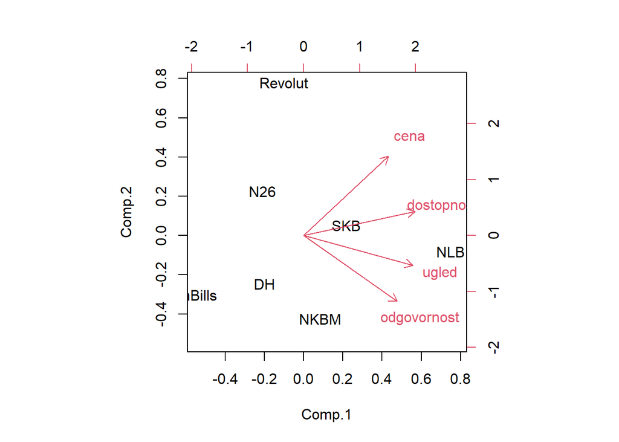

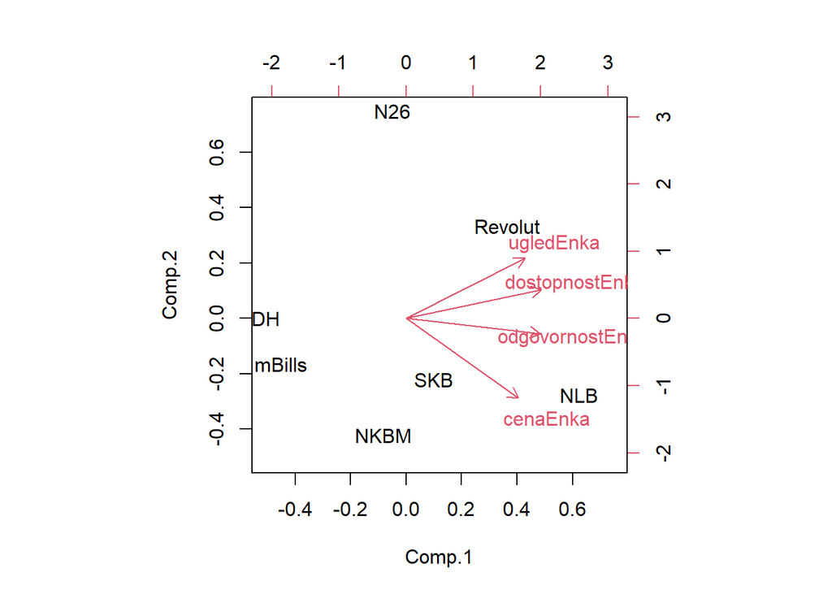

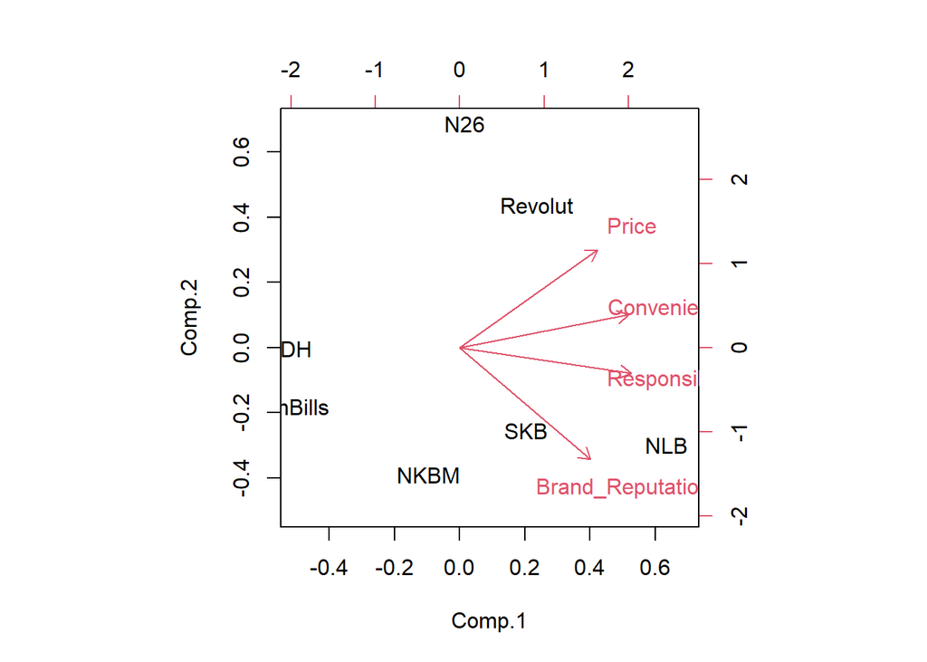

```r
pc.perc <- princomp(final, cor = TRUE)

ggarrange(biplot(pc.perc), biplot(pc.percEnka), biplot(pc.percNA), ncol = 3, nrow = 1)
```

## 6. Pricing testing

Lets look at our Van Westendorp pricing analysis. In our survey VW analysis was measured with the following Qs: Q26 Q27 Q28 Q29.

```r
library(ggplot2)

myDataVW <- mydata

# DATA CLEANUP: We need to clean the data for these for Qs. We need to filter the people who did not answer this Qs.

myDataVW <- myDataVW[-8, ]
myDataVW <- myDataVW[-213, ]
myDataVW <- myDataVW[-196, ]
myDataVW <- myDataVW[-175, ]
myDataVW <- myDataVW[-168, ]
myDataVW <- myDataVW[-103, ]
myDataVW <- myDataVW[-78, ]
myDataVW <- myDataVW[-33, ]


# Van Westerdorp analysis TAKE 2
myDataVW$Q26 <- as.numeric(as.character(myDataVW$Q26))
myDataVW$Q27 <- as.numeric(as.character(myDataVW$Q27))
myDataVW$Q28 <- as.numeric(as.character(myDataVW$Q28))
myDataVW$Q29 <- as.numeric(as.character(myDataVW$Q29))


library(pricesensitivitymeter)
psm_out <- psm_analysis(toocheap = myDataVW$Q26,
             cheap = myDataVW$Q27,
             expensive = myDataVW$Q28,
             tooexpensive = myDataVW$Q29,
             validate = TRUE)

str(psm_out)
```

```
## List of 11
##  $ data_input        :'data.frame':  110 obs. of  4 variables:
##   ..$ toocheap    : num [1:110] 3 1 0 1 1 2 2 2 2 10 ...
##   ..$ cheap       : num [1:110] 5 2 6 3 5 5 3 10 4 15 ...
##   ..$ expensive   : num [1:110] 10 5 10 10 9 7 10 25 8 40 ...
##   ..$ tooexpensive: num [1:110] 13 7 15 15 10 10 13 30 10 50 ...
##  $ validated         : logi TRUE
##  $ invalid_cases     : int 99
##  $ total_sample      : int 209
##  $ data_vanwestendorp:'data.frame':  27 obs. of  7 variables:
##   ..$ price             : num [1:27] 0 1 2 3 4 5 6 7 8 9 ...
##   ..$ ecdf_toocheap     : num [1:27] 0.873 0.7 0.491 0.282 0.264 ...
##   ..$ ecdf_cheap        : num [1:27] 1 0.955 0.909 0.709 0.609 ...
##   ..$ ecdf_expensive    : num [1:27] 0 0 0 0.00909 0.01818 ...
##   ..$ ecdf_tooexpensive : num [1:27] 0 0 0 0 0.00909 ...
##   ..$ ecdf_not_cheap    : num [1:27] 0 0.0455 0.0909 0.2909 0.3909 ...
##   ..$ ecdf_not_expensive: num [1:27] 1 1 1 0.991 0.982 ...
##  $ pricerange_lower  : num 3
##  $ pricerange_upper  : num 13
##  $ idp               : num 8
##  $ opp               : num 7
##  $ weighted          : logi FALSE
##  $ NMS               : logi FALSE
##  - attr(*, "class")= chr "psm"
```

```r
head(psm_out$data_input)
```

```
##    toocheap cheap expensive tooexpensive
## 5         3     5        10           13
## 7         1     2         5            7
## 11        0     6        10           15
## 12        1     3        10           15
## 15        1     5         9           10
## 16        2     5         7           10
```

```r
head(psm_out$data_vanwestendorp)
```

```
##   price ecdf_toocheap ecdf_cheap ecdf_expensive ecdf_tooexpensive
## 1     0     0.8727273  1.0000000    0.000000000       0.000000000
## 2     1     0.7000000  0.9545455    0.000000000       0.000000000
## 3     2     0.4909091  0.9090909    0.000000000       0.000000000
## 4     3     0.2818182  0.7090909    0.009090909       0.000000000
## 5     4     0.2636364  0.6090909    0.018181818       0.009090909
## 6     5     0.1090909  0.3727273    0.127272727       0.009090909
##   ecdf_not_cheap ecdf_not_expensive
## 1     0.00000000          1.0000000
## 2     0.04545455          1.0000000
## 3     0.09090909          1.0000000
## 4     0.29090909          0.9909091
## 5     0.39090909          0.9818182
## 6     0.62727273          0.8727273
```

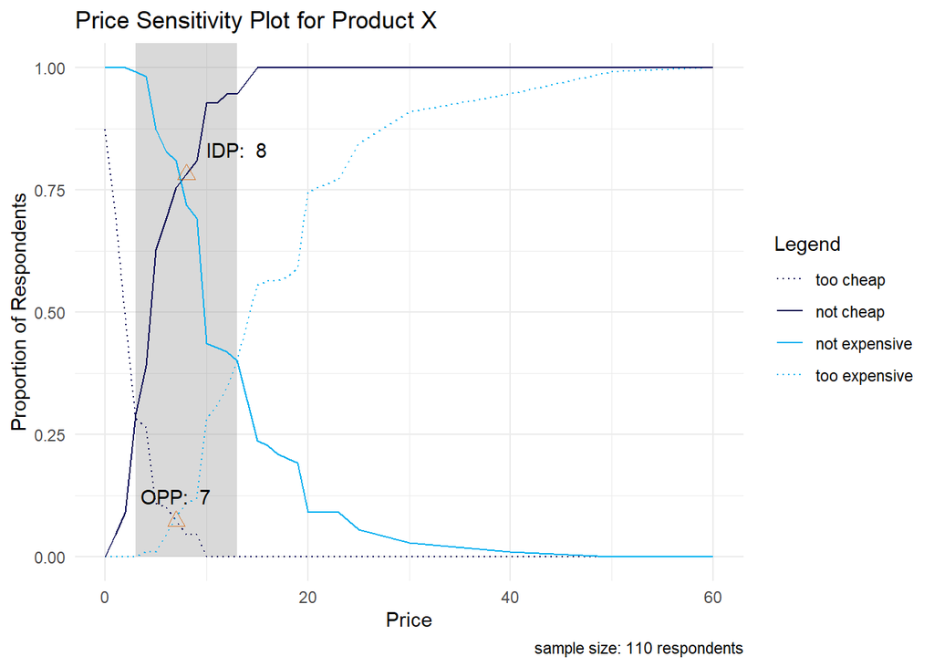

```r
psmplot <-  ggplot(data = psm_out$data_vanwestendorp, aes(x = price)) +
  annotate(geom = "rect", # shaded background area for range of acceptable prices
           xmin = psm_out$pricerange_lower,
           xmax = psm_out$pricerange_upper,
           ymin = 0, ymax = Inf,
           fill="grey50", alpha = 0.3) +
  geom_line(aes(y = ecdf_toocheap, # line: too cheap
                colour = "too cheap",
                linetype = "too cheap"),
            size= .5) +
  geom_line(aes(y = ecdf_tooexpensive, # line: too expensive
                colour = "too expensive",
                linetype = "too expensive"),
            size = .5) +
  geom_line(aes(y = ecdf_not_cheap, # line: not cheap
                colour = "not cheap",
                linetype = "not cheap"),
            size = .5) +
  geom_line(aes(y = ecdf_not_expensive, # line: not expensive
                colour = "not expensive",
                linetype = "not expensive"),
            size = .5) +
  annotate(geom = "point", # Indifference Price Point (intersection of "cheap" and "expensive")
           x = psm_out$idp,
           y = psm_out$data_vanwestendorp$ecdf_not_cheap[psm_out$data_vanwestendorp$price == psm_out$idp],
           size = 3,
           shape = 2,
           colour = "#D55E00",
           fill = "#D55E00",
           alpha = .8) +
  annotate(geom = "point", # Optimal Price Point (intersection of "too cheap" and "too expensive")
           x = psm_out$opp,
           y = psm_out$data_vanwestendorp$ecdf_toocheap[psm_out$data_vanwestendorp$price == psm_out$opp],
           size = 3,
           shape = 2,
           colour = "#D55E00",
           fill = "#D55E00",
           alpha = 0.8)


# Update plot with labels and colors
psmplot +
  labs(x = "Price",
       y = "Proportion of Respondents",
       title = "Price Sensitivity Plot for Product X",
       caption = paste("sample size:",
                       psm_out$total_sample - psm_out$invalid_cases,
                       "respondents"))  +
  scale_colour_manual(name = "Legend",
                      values = c("too cheap" = "#040453",
                                 "not cheap" = "#040453",
                                 "not expensive" = "#00b0f0",
                                 "too expensive" = "#00b0f0")) +
  scale_linetype_manual(name="Legend",
                        values = c("too cheap" = "dotted",
                                   "not cheap" = "solid",
                                   "not expensive" = "solid",
                                   "too expensive" = "dotted")) +
  annotate(geom = "text", # Label of Indifference Price Point
           x = psm_out$idp + 5,
           y = psm_out$data_vanwestendorp$ecdf_not_cheap[psm_out$data_vanwestendorp$price == psm_out$idp] + .05,
           label = paste("IDP: ", psm_out$idp)) +
  annotate(geom = "text", # Label of Optimal Price Point
           x = psm_out$opp,
           y = psm_out$data_vanwestendorp$ecdf_toocheap[psm_out$data_vanwestendorp$price == psm_out$opp] + .05,
           label = paste("OPP: ", psm_out$opp)) +
  theme_minimal()
```

```r
myDataPriceFourQ <- data.frame(myDataVW$Q26, myDataVW$Q27, myDataVW$Q28, myDataVW$Q29)
```

## 7. Social proof testing

Here we are cleaning our data:

```r
# TODO: Wont Do.

# use correlation between them and see if they are very similar you group them

# Box plots for each product specific product
# Just show them graphically
# x products, y values from 1-7

# t-test for each product, to see if 5.1 is statistically signifanct than 4
# t-test for one arithmetic mean

# test of propotions, more than half of people would be interested in this product, cutoff 4
```

## 8. Additional important key parts (hypothesis)

Here we are cleaning our data:

```r
# TODO: Wont Do.
# They ARE prepared to pay more!?
# Why DOES 1/3 not use the packages!?
# Do people see n26 as more secure for online shopping!?
# Include case studies from abroad
```

## 9. Segmentation

# I want to segment our customers

#### We need to segment the customers in different segments.

#### Our variables will be:

#### Max 5 variables: (iteracija 10)

#### How sustainable is your lifestyle? (stands for Attitude) => avg. 1-7

#### How much do you consider sustainability when making purchases?

#### How much are you prepared to use sustainable packages? => 1-7

#### How much are you willing to pay for a normal package: Q18

#### How much are you willing to pay for a sustainable package: Q24

#### How much do you use financial products? (stands for Usage) => avg. 1- => Didnt use

```r
segmentationData <- mydata

# How much do you use financial products? (stands for Usage) => avg. 1-7 => maybe added maybe not
# How sustainable is your lifestyle? (stands for Attitude) => avg. 1-7
viewsOnSustainability
```

```
##   [1] 4.4 3.8 6.6 5.2 5.4 3.6 5.0 6.0 6.2 4.4 6.2 4.0 2.2 4.0 4.6 5.6 3.8 6.2
##  [19] 6.0 3.8 6.4 5.2 3.2 6.6 3.8 5.6 6.4 4.4 6.0 6.2 5.8 4.8 5.6 7.0 5.4 5.0
##  [37] 4.8 5.2 4.0 3.4 5.2 6.0 6.6 5.6 3.4 5.2 4.4 6.4 6.6 6.6 5.6 3.6 4.8 4.8
##  [55] 5.8 4.8 5.0 4.8 3.8 5.2 3.8 5.8 6.4 6.6 4.4 3.2 5.6 5.6 5.6 5.6 3.4 5.0
##  [73] 6.0 4.6 5.8 5.8 5.0 7.0 5.4 4.6 6.0 4.6 5.2 6.4 6.0 5.6 6.4 5.0 6.0 5.0
##  [91] 5.4 3.6 3.6 3.6 6.6 6.4 4.4 4.2 4.6 6.0 6.2 5.0 4.8 4.4 5.2 6.8 3.0 4.2
## [109] 6.4 3.6 5.6 4.8 5.4 6.4 5.6 4.4 5.2 5.0 4.0 5.0 6.0 4.2 4.8 5.8 4.4 5.4
## [127] 5.0 6.4 5.2 4.0 5.8 4.0 6.4 5.4 6.4 5.0 4.6 5.0 5.0 5.4 3.8 5.6 5.2 4.4
## [145] 6.6 5.8 5.4 4.0 4.8 6.0 2.2 3.6 6.0 4.8 5.4 5.6 5.2 5.6 6.4 5.6 4.6 6.0
## [163] 4.2 4.6 4.2 6.0 6.0 5.6 5.0 2.0 5.6 4.0 5.6 5.4 5.0 7.0 7.0 5.0 4.4 4.6
## [181] 5.8 3.4 5.8 5.2 5.6 5.6 5.6 5.4 5.0 2.6 3.8 6.2 6.0 4.8 7.0 7.0 6.0 6.4
## [199] 6.2 4.4 4.0 6.8 5.2 5.6 6.0 6.2 3.0 5.0 5.6 4.8 5.4 3.4 6.2 6.4 6.2 7.0
## [217] 6.4
```

```r
typeof(viewsOnSustainability)
```

```
## [1] "double"
```

```r
is.numeric(viewsOnSustainability)
```

```
## [1] TRUE
```

```r
# segmentationData

segmentationData["LS_avg"] <- viewsOnSustainability
# segmentationData["LS_avg"]

# Q21: How much do you consider sustainability when making purchases?
nrow(segmentationData[c("Q21a")])
```

```
## [1] 217
```

```r
# How much are you prepared to use sustainable packages? => 1-7
segmentationData["Q23b"] <- as.numeric(as.character(segmentationData[ ,"Q23b"]))
# segmentationData["Q23b"]

# How much are you willing to pay for a normal package: Q18
segmentationData["Q18"] <- as.numeric(as.character(segmentationData[ ,"Q18"]))
# segmentationData["Q18"]

# How much are you willing to pay for a sustainable package: Q24
segmentationData["Q24"] <- as.numeric(as.character(segmentationData[ ,"Q24"]))
# segmentationData["Q24"]


summary(segmentationData[c("LS_avg", "Q21a", "Q23b", "Q18", "Q24")])
```

```
##      LS_avg           Q21a            Q23b            Q18
##  Min.   :2.000   Min.   :1.000   Min.   :1.000   Min.   : 0.000
##  1st Qu.:4.600   1st Qu.:4.000   1st Qu.:3.000   1st Qu.: 2.000
##  Median :5.200   Median :5.000   Median :5.000   Median : 5.000
##  Mean   :5.188   Mean   :4.475   Mean   :4.419   Mean   : 5.313
##  3rd Qu.:6.000   3rd Qu.:5.000   3rd Qu.:6.000   3rd Qu.: 8.000
##  Max.   :7.000   Max.   :7.000   Max.   :7.000   Max.   :15.000
##       Q24
##  Min.   : 0.000
##  1st Qu.: 4.000
##  Median : 6.000
##  Mean   : 6.866
##  3rd Qu.:10.000
##  Max.   :19.000
```

```r
segmentationData_std <- as.data.frame(scale(segmentationData[c("LS_avg", "Q21a", "Q23b", "Q18", "Q24")]))

# segmentationData_std

# Finding outliers
segmentationData_std$Dissimilarity = sqrt(segmentationData_std$LS_avg^2 + segmentationData_std$Q21a^2 + segmentationData_std$Q23b^2 + segmentationData_std$Q18^2 + segmentationData_std$Q24^2)

head(segmentationData_std[order(-segmentationData_std$Dissimilarity), ], 5)
```

```
##        LS_avg      Q21a      Q23b        Q18       Q24 Dissimilarity
## 153 -2.894589 -1.721948 -1.743463 -1.4380759 -1.570071      4.349322
## 109 -2.119603 -2.417782 -1.743463 -1.4380759 -1.570071      4.232167
## 72  -1.732111 -2.417782 -1.743463 -1.4380759 -1.570071      4.052003
## 172 -3.088335 -1.026115 -1.743463 -0.3554654 -1.570071      4.027638
## 79   1.755324  1.757221  1.315821  1.2684503  2.317172      3.857282
```

```r
# print(segmentationData[82, ]) # Checking outliers

# nrow(segmentationData)
```

```r
segmentationData_std_NoDissimilarity <- segmentationData_std # this step is REQUIRED, REMOVE DISSIMILARITY BEFORE DOING FURTHER ANALYSIS
segmentationData_std_NoDissimilarity$Dissimilarity <- NULL

round(cor(segmentationData_std_NoDissimilarity), 2)
```

```
##        LS_avg Q21a  Q23b   Q18  Q24
## LS_avg   1.00 0.51  0.27  0.08 0.15
## Q21a     0.51 1.00  0.24  0.10 0.20
## Q23b     0.27 0.24  1.00 -0.01 0.23
## Q18      0.08 0.10 -0.01  1.00 0.70
## Q24      0.15 0.20  0.23  0.70 1.00
```

```r
library(factoextra)
```

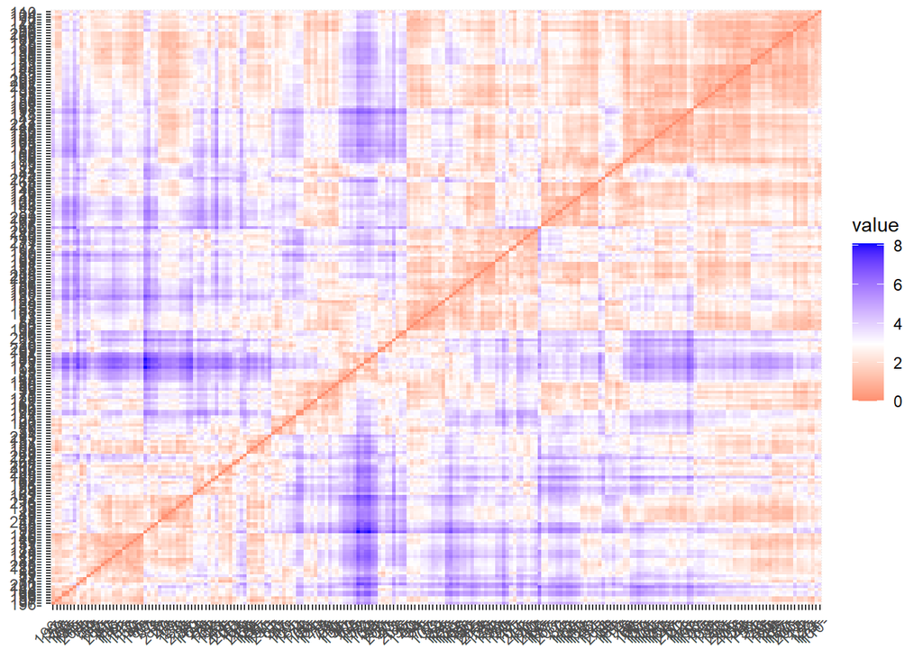

```r
Distances <- get_dist(segmentationData_std_NoDissimilarity, method = "euclidian")

fviz_dist(Distances)
```

```r
get_clust_tendency(segmentationData_std_NoDissimilarity, n = nrow(segmentationData_std_NoDissimilarity) - 1, graph = FALSE)
```

```
## $hopkins_stat
## [1] 0.6412715
##
## $plot
## NULL
```

```r
library(dplyr)

(WARD <- segmentationData_std_NoDissimilarity %>% get_dist(method = "euclidian") %>% hclust(method = "ward.D2"))
```

```
##
## Call:
## hclust(d = ., method = "ward.D2")
##
## Cluster method   : ward.D2
## Distance         : euclidean
## Number of objects: 217
```